# Bellabeat Case Study

Eve Kudriavska

2025-03-26

# Bellabeat Case Study

## Introduction

[figure not shown]

Bellabeat is a high-tech manufacturer of health-focused products for women such as wellness devices which record sleep, stress, daily activities, water intake, menstrual cycle, ovulation, etc. Products are utilized through the application based on a membership program. Membership program provides guidance on nutrition, activity, sleep, health and beauty, and mindfulness through the App based on their lifestyle and goals. The company was founded in 2013.

## Ask

### Main stakeholders

Urška Sršen: Bellabeat’s cofounder and Chief Creative Ocer Sando Mur: Mathematician and Bellabeat’s cofounder; key member of the Bellabeat executive team.

### Business task

Comprehensive analysis of the usage of smart non- Bellabeat wellness devices by customers. Identify trends in the smart devices usage, which can be related to Bellabeat customers, and use the findings in building Bellabeat market strategy.

### Deliverables

1. A clear summary of the business task
2. A description of all data sources used
3. Documentation of any cleaning or manipulation of data
4. A summary of data analysis
5. Supporting visualizations and key findings
6. Top high-level content recommendations based on the analysis.

## Prepare

### Data licensing, security, privacy and accessibility

The data we use is FitBit Fitness Tracker Data (CC0: Public Domain, dataset made available through Mobius (Owner)).

All participants gave their consent to the submission of personal tracker data, including minute-level output for physical activity, heart rate, and sleep monitoring. It includes information about daily activity, steps, and heart rate that can be used to explore users’ habits.

### The source

**Data source**: https://zenodo.org/records/53894#.X9oeh3Uzaao.

**Description**: This dataset was generated by respondents to a distributed survey via Amazon Mechanical Turk between 03.12.2016-05.12.2016. The dataset consists of 29 files in csv format.

### Data bias

The current data sample is quite small and might not be representative of the whole population.

### Limitations

There is no personal data such as age, ethnicity, lifestyle, occupation, health conditions, geographical locations included in the sample.

### Issues

The data was collected in 2016, therefore it might be outdated.

## Prepare

### Tools

For the initial dataset browsing I use Google sheets to quickly explore data. For the cleaning, preparing and analyzing data I will use R language in online RStudio via posit.cloud. The final report will be presented in RMarkdown file.

### Exploration of data

I have checked the dataset in Google sheets and identified four main types of observations recorded by a tracker: sleep, calories, weight and steps. We will be looking into corresponding data tables, intensities table and activity_merged table for the further insights. I identified some issues with Date and Time, as well as zero values, which might scew the analysis. We will clean the dataset in the Studio.

### Further exploration and cleaning

Loading the packages.

Loading the files.

```r
activity <- read.csv("dailyActivity_merged.csv")
calories <- read.csv("hourlyCalories_merged.csv")
intensities <- read.csv("hourlyIntensities_merged.csv")
steps <- read.csv("hourlySteps_merged.csv")
sleep <- read.csv("sleepDay_merged.csv")
weight <- read.csv("weightLogInfo_merged.csv")
```

Getting the summary of the files to check for the initial issues and get some insights.

```r
head(activity)
```

```
##           Id ActivityDate TotalSteps TotalDistance TrackerDistance
## 1 1503960366    4/12/2016      13162          8.50            8.50
## 2 1503960366    4/13/2016      10735          6.97            6.97
## 3 1503960366    4/14/2016      10460          6.74            6.74
## 4 1503960366    4/15/2016       9762          6.28            6.28
## 5 1503960366    4/16/2016      12669          8.16            8.16
## 6 1503960366    4/17/2016       9705          6.48            6.48
##   LoggedActivitiesDistance VeryActiveDistance ModeratelyActiveDistance
## 1                        0               1.88                     0.55
## 2                        0               1.57                     0.69
## 3                        0               2.44                     0.40
## 4                        0               2.14                     1.26
## 5                        0               2.71                     0.41
## 6                        0               3.19                     0.78
##   LightActiveDistance SedentaryActiveDistance VeryActiveMinutes
## 1                6.06                       0                25
## 2                4.71                       0                21
## 3                3.91                       0                30
## 4                2.83                       0                29
## 5                5.04                       0                36
## 6                2.51                       0                38
##   FairlyActiveMinutes LightlyActiveMinutes SedentaryMinutes Calories
## 1                  13                  328              728     1985
## 2                  19                  217              776     1797
## 3                  11                  181             1218     1776
## 4                  34                  209              726     1745
## 5                  10                  221              773     1863
## 6                  20                  164              539     1728
```

Issues with the date format are identified. The date format is not consisted throughout the tables. For each table date and time will be separated and formatted consistently.

## Process

### Formatting Date and Time

Formatting the date/time to ““%m/%d/%Y”” in the activity table.

```r
activity$ActivityDate = as.POSIXct(activity$ActivityDate, format = "%m/%d/%Y", tz = Sys.timezone())
activity$date <- format(activity$ActivityDate, format = "%m/%d/%y")
```

Checking results for activity table.

```r
head(activity)
```

```
##           Id ActivityDate TotalSteps TotalDistance TrackerDistance
## 1 1503960366   2016-04-12      13162          8.50            8.50
## 2 1503960366   2016-04-13      10735          6.97            6.97
## 3 1503960366   2016-04-14      10460          6.74            6.74
## 4 1503960366   2016-04-15       9762          6.28            6.28
## 5 1503960366   2016-04-16      12669          8.16            8.16
## 6 1503960366   2016-04-17       9705          6.48            6.48
##   LoggedActivitiesDistance VeryActiveDistance ModeratelyActiveDistance
## 1                        0               1.88                     0.55
## 2                        0               1.57                     0.69
## 3                        0               2.44                     0.40
## 4                        0               2.14                     1.26
## 5                        0               2.71                     0.41
## 6                        0               3.19                     0.78
##   LightActiveDistance SedentaryActiveDistance VeryActiveMinutes
## 1                6.06                       0                25
## 2                4.71                       0                21
## 3                3.91                       0                30
## 4                2.83                       0                29
## 5                5.04                       0                36
## 6                2.51                       0                38
##   FairlyActiveMinutes LightlyActiveMinutes SedentaryMinutes Calories     date
## 1                  13                  328              728     1985 04/12/16
## 2                  19                  217              776     1797 04/13/16
## 3                  11                  181             1218     1776 04/14/16
## 4                  34                  209              726     1745 04/15/16
## 5                  10                  221              773     1863 04/16/16
## 6                  20                  164              539     1728 04/17/16
```

Checking the calories table.

```r
head(calories)
```

```
##           Id          ActivityHour Calories
## 1 1503960366 4/12/2016 12:00:00 AM       81
## 2 1503960366  4/12/2016 1:00:00 AM       61
## 3 1503960366  4/12/2016 2:00:00 AM       59
## 4 1503960366  4/12/2016 3:00:00 AM       47
## 5 1503960366  4/12/2016 4:00:00 AM       48
## 6 1503960366  4/12/2016 5:00:00 AM       48
```

Date and time need to be split and formatted.

```r
calories$ActivityHour = as.POSIXct(calories$ActivityHour, format = "%m/%d/%Y %I:%M:%S %p", tz=Sys.timezone())
calories$time <- format(calories$ActivityHour, format = "%H:%M:%S")
calories$date <- format(calories$ActivityHour, format = "%m/%d/%y")
```

Checking the Steps table.

```r
head(steps)
```

```
##           Id          ActivityHour StepTotal
## 1 1503960366 4/12/2016 12:00:00 AM       373
## 2 1503960366  4/12/2016 1:00:00 AM       160
## 3 1503960366  4/12/2016 2:00:00 AM       151
## 4 1503960366  4/12/2016 3:00:00 AM         0
## 5 1503960366  4/12/2016 4:00:00 AM         0
## 6 1503960366  4/12/2016 5:00:00 AM         0
```

Activity Hour column should be split in Date and Time and formatted.

```r
steps$ActivityHour = as.POSIXct(steps$ActivityHour, format = "%m/%d/%Y %I:%M:%S %p", tz=Sys.timezone())
 steps$time <- format(steps$ActivityHour, format = "%H:%M:%S")
 steps$date <- format(steps$ActivityHour, format = "%m/%d/%y")
```

Checking date/time issues the sleep table.

```r
head(sleep)
```

```
##           Id              SleepDay TotalSleepRecords TotalMinutesAsleep
## 1 1503960366 4/12/2016 12:00:00 AM                 1                327
## 2 1503960366 4/13/2016 12:00:00 AM                 2                384
## 3 1503960366 4/15/2016 12:00:00 AM                 1                412
## 4 1503960366 4/16/2016 12:00:00 AM                 2                340
## 5 1503960366 4/17/2016 12:00:00 AM                 1                700
## 6 1503960366 4/19/2016 12:00:00 AM                 1                304
##   TotalTimeInBed
## 1            346
## 2            407
## 3            442
## 4            367
## 5            712
## 6            320
```

SleepDay should be split into Date and Time columns, and formatted accordingly.

```r
sleep$SleepDay=as.POSIXct(sleep$SleepDay, format = "%m/%d/%Y %I:%M:%S %p", tz=Sys.timezone())
sleep$date <- format(sleep$SleepDay, format = "%m/%d/%y")
sleep$time <- format(sleep$SleepDay, format = "%H:%M:%S")
```

Checking date/time issues in the intensities table.

```r
head(intensities)
```

```
##           Id          ActivityHour TotalIntensity AverageIntensity
## 1 1503960366 4/12/2016 12:00:00 AM             20         0.333333
## 2 1503960366  4/12/2016 1:00:00 AM              8         0.133333
## 3 1503960366  4/12/2016 2:00:00 AM              7         0.116667
## 4 1503960366  4/12/2016 3:00:00 AM              0         0.000000
## 5 1503960366  4/12/2016 4:00:00 AM              0         0.000000
## 6 1503960366  4/12/2016 5:00:00 AM              0         0.000000
```

Activity hour should to be split in Date and Time, formatted.

```r
intensities$ActivityHour=as.POSIXct(intensities$ActivityHour, format="%m/%d/%Y %I:%M:%S %p", tz=Sys.timezone())
intensities$time <- format(intensities$ActivityHour, format = "%H:%M:%S")
intensities$date <- format(intensities$ActivityHour, format = "%m/%d/%y")
```

Checking time/date issues in the weight table.

```r
head(weight)
```

```
##           Id                  Date WeightKg WeightPounds Fat   BMI
## 1 1503960366  5/2/2016 11:59:59 PM     52.6     115.9631  22 22.65
## 2 1503960366  5/3/2016 11:59:59 PM     52.6     115.9631  NA 22.65
## 3 1927972279  4/13/2016 1:08:52 AM    133.5     294.3171  NA 47.54
## 4 2873212765 4/21/2016 11:59:59 PM     56.7     125.0021  NA 21.45
## 5 2873212765 5/12/2016 11:59:59 PM     57.3     126.3249  NA 21.69
## 6 4319703577 4/17/2016 11:59:59 PM     72.4     159.6147  25 27.45
##   IsManualReport        LogId
## 1           True 1.462234e+12
## 2           True 1.462320e+12
## 3          False 1.460510e+12
## 4           True 1.461283e+12
## 5           True 1.463098e+12
## 6           True 1.460938e+12
```

Date column needs to be split in Time and Date, formatted.

```r
weight$Date=as.POSIXct(weight$Date, format="%m/%d/%Y %I:%M:%S %p", tz=Sys.timezone())
weight$time <- format(weight$Date, format = "%H:%M:%S")
weight$date <- format(weight$Date, format = "%m/%d/%y")
```

### Removing zero values and blanks

We keep cleaning data. Lets get rid of blanks and zero values in some columns of the tables. Those values can influence summary of the tables, and further scew the analysis.

```r
head(activity)
```

```
##           Id ActivityDate TotalSteps TotalDistance TrackerDistance
## 1 1503960366   2016-04-12      13162          8.50            8.50
## 2 1503960366   2016-04-13      10735          6.97            6.97
## 3 1503960366   2016-04-14      10460          6.74            6.74
## 4 1503960366   2016-04-15       9762          6.28            6.28
## 5 1503960366   2016-04-16      12669          8.16            8.16
## 6 1503960366   2016-04-17       9705          6.48            6.48
##   LoggedActivitiesDistance VeryActiveDistance ModeratelyActiveDistance
## 1                        0               1.88                     0.55
## 2                        0               1.57                     0.69
## 3                        0               2.44                     0.40
## 4                        0               2.14                     1.26
## 5                        0               2.71                     0.41
## 6                        0               3.19                     0.78
##   LightActiveDistance SedentaryActiveDistance VeryActiveMinutes
## 1                6.06                       0                25
## 2                4.71                       0                21
## 3                3.91                       0                30
## 4                2.83                       0                29
## 5                5.04                       0                36
## 6                2.51                       0                38
##   FairlyActiveMinutes LightlyActiveMinutes SedentaryMinutes Calories     date
## 1                  13                  328              728     1985 04/12/16
## 2                  19                  217              776     1797 04/13/16
## 3                  11                  181             1218     1776 04/14/16
## 4                  34                  209              726     1745 04/15/16
## 5                  10                  221              773     1863 04/16/16
## 6                  20                  164              539     1728 04/17/16
```

Cleaning the activity table from zero and blanks in TotalSteps column.

```r
activity_cleaned <- activity %>%
  filter(!is.na(activity$TotalSteps) & activity$TotalSteps != 0)
```

## Analyse

Exploring cleaned dataset, identifying trends and insights.

### Relationship between features

Exploring how many Unique ID use the trackers,and how they use the tracker.

```r
n_distinct(activity$Id)
```

```
## [1] 33
```

```r
n_distinct(calories$Id)
```

```
## [1] 33
```

```r
n_distinct(steps$Id)
```

```
## [1] 33
```

```r
n_distinct(intensities$Id)
```

```
## [1] 33
```

```r
n_distinct(sleep$Id)
```

```
## [1] 24
```

```r
n_distinct(weight$Id)
```

```
## [1] 8
```

The results are 33, 33, 33, 33, 24,8. Therefore we can conclude that we have 33 unique IDs for activity, steps, calories and intensities. All these observations are made automatically by a tracker. 24 unique IDs use sleep feature, which is also recorded automatically while users are wearing the device. And we know that 8 Unique Ids uses weight log feature, which in recorded manually by a user.

Checking amount of observation days per each table.

```r
n_distinct(activity$date)
```

```
## [1] 31
```

```r
n_distinct(calories$date)
```

```
## [1] 31
```

```r
n_distinct(steps$date)
```

```
## [1] 31
```

```r
n_distinct(intensities$date)
```

```
## [1] 31
```

```r
n_distinct(sleep$date)
```

```
## [1] 31
```

```r
n_distinct(weight$date)
```

```
## [1] 31
```

Each table has 31 days of observations, which proves the consistency of the record.

Therefore, we can conclude that the dataset contains observations of 33 users over 31 days.

## Visuals

Lets create some visualisations to compare the usage of sleep, steps and weight features.

```r
install.packages("ggvenn")
```

```r
library(ggplot2)
library(ggvenn)
library(grid)
```

Creating Id list.

```r
id_list <- list(
  weight = weight$Id,
  steps = steps$Id,
  sleep = sleep$Id
)
```

Creating a Venn Diagram

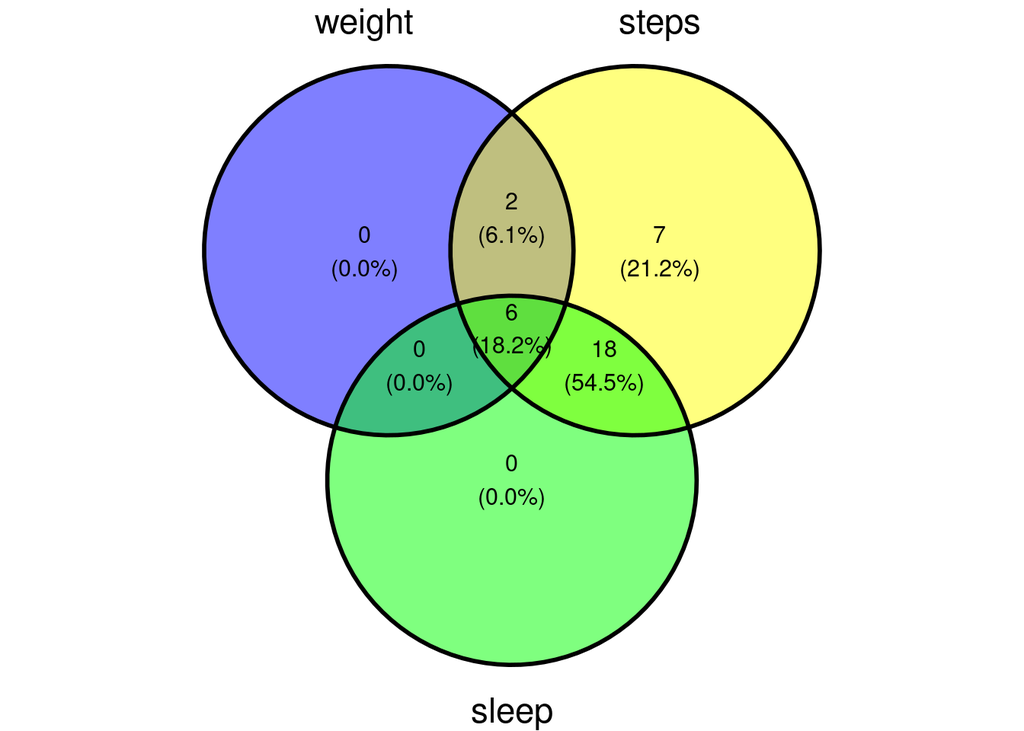

```r
ggvenn(id_list)
```

Only 24 users wear their monitor at night. And, we can clearly see that only 8 users monitor their weight, which is recorded manually. We might speculate that the reason for this is the way weight is logged in. It might not be easy or user friendly. Here is a possible gap in the market, which Bellabeat might want to explore.

Let’s create a bar chart to further analyse the relationship between these features.

```r
weight_count <- n_distinct(weight$Id)
steps_count <- n_distinct(steps$Id)
sleep_count <- n_distinct(sleep$Id)
```

Creating a data frame for visualization

```r
usage_summary <- data.frame(
  Activity = c("weight", "steps", "sleep"),
  UserCount = c(weight_count, steps_count, sleep_count)
)
```

Create a bar chart to compare how many Ids are using sleep, steps and weight functions

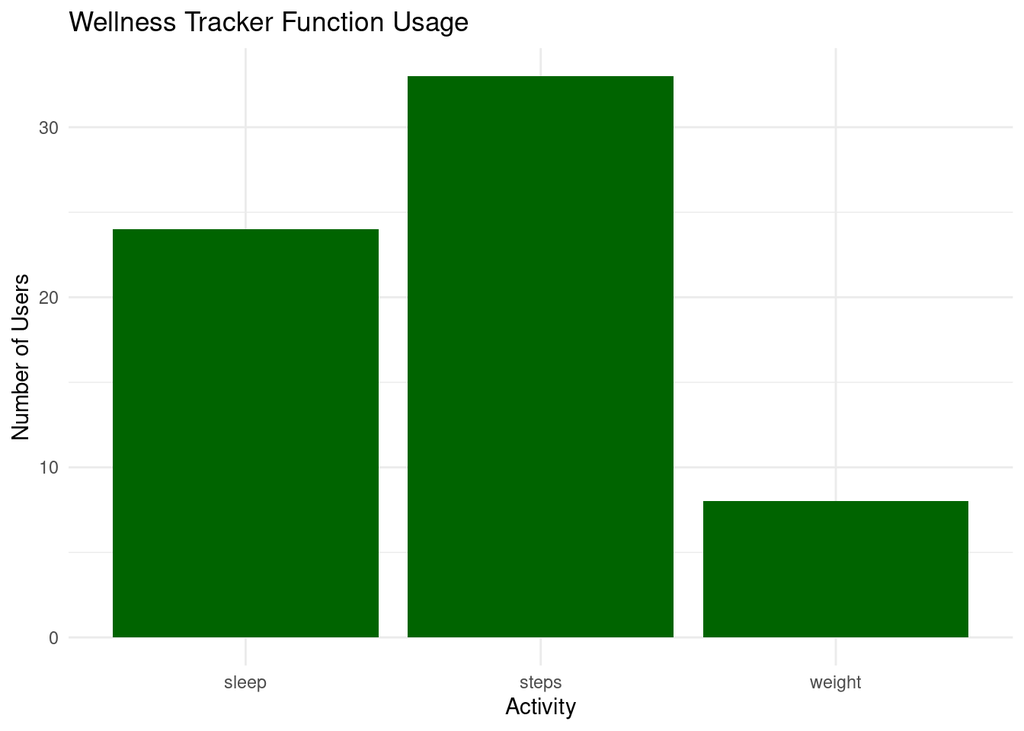

```r
ggplot(usage_summary, aes(x = Activity, y = UserCount)) +
  geom_bar(stat = "identity", fill = "darkgreen") +
  labs(
    title = "Wellness Tracker Function Usage",
    x = "Activity",
    y = "Number of Users"
  ) +
  theme_minimal()
```

The bar chat shows that steps count feature is the most popular, and all 33 Ids are using it. The sleep feature is the second popular. And weight is the last maybe due to the manual or unfriendly imput of data.

Checking further summary of the tables.

```r
activity_cleaned %>%
  select(TotalSteps,
         TotalDistance,
         SedentaryMinutes, Calories) %>%
  summary()
```

```
##    TotalSteps    TotalDistance   SedentaryMinutes    Calories
##  Min.   :    4   Min.   : 0.00   Min.   :   0.0   Min.   :  52
##  1st Qu.: 4923   1st Qu.: 3.37   1st Qu.: 721.5   1st Qu.:1856
##  Median : 8053   Median : 5.59   Median :1021.0   Median :2220
##  Mean   : 8319   Mean   : 5.98   Mean   : 955.8   Mean   :2361
##  3rd Qu.:11092   3rd Qu.: 7.90   3rd Qu.:1189.0   3rd Qu.:2832
##  Max.   :36019   Max.   :28.03   Max.   :1440.0   Max.   :4900
```

```r
activity_cleaned %>%
  select(VeryActiveMinutes, FairlyActiveMinutes, LightlyActiveMinutes) %>%
  summary()
```

```
##  VeryActiveMinutes FairlyActiveMinutes LightlyActiveMinutes
##  Min.   :  0.00    Min.   :  0.00      Min.   :  0.0
##  1st Qu.:  0.00    1st Qu.:  0.00      1st Qu.:146.5
##  Median :  7.00    Median :  8.00      Median :208.0
##  Mean   : 23.02    Mean   : 14.78      Mean   :210.0
##  3rd Qu.: 35.00    3rd Qu.: 21.00      3rd Qu.:272.0
##  Max.   :210.00    Max.   :143.00      Max.   :518.0
```

```r
sleep %>%
  select(TotalSleepRecords, TotalMinutesAsleep, TotalTimeInBed) %>%
  summary()
```

```
##  TotalSleepRecords TotalMinutesAsleep TotalTimeInBed
##  Min.   :1.000     Min.   : 58.0      Min.   : 61.0
##  1st Qu.:1.000     1st Qu.:361.0      1st Qu.:403.0
##  Median :1.000     Median :433.0      Median :463.0
##  Mean   :1.119     Mean   :419.5      Mean   :458.6
##  3rd Qu.:1.000     3rd Qu.:490.0      3rd Qu.:526.0
##  Max.   :3.000     Max.   :796.0      Max.   :961.0
```

```r
summary(steps)
```

```
##        Id             ActivityHour                      StepTotal
##  Min.   :1.504e+09   Min.   :2016-04-12 00:00:00.00   Min.   :    0.0
##  1st Qu.:2.320e+09   1st Qu.:2016-04-19 01:00:00.00   1st Qu.:    0.0
##  Median :4.445e+09   Median :2016-04-26 06:00:00.00   Median :   40.0
##  Mean   :4.848e+09   Mean   :2016-04-26 11:46:42.58   Mean   :  320.2
##  3rd Qu.:6.962e+09   3rd Qu.:2016-05-03 19:00:00.00   3rd Qu.:  357.0
##  Max.   :8.878e+09   Max.   :2016-05-12 15:00:00.00   Max.   :10554.0
##      time               date
##  Length:22099       Length:22099
##  Class :character   Class :character
##  Mode  :character   Mode  :character
##
##
##
```

```r
view(steps)
```

[figure not shown]

We can see a positive correlations between Total time in bed vs Total time asleep.

### Merging data

Lets merge sleep and activity by ID and Date to create comprehensice visualisations.

```r
merged_data <- merge(sleep, activity_cleaned, by=c('Id', 'date'))
head(merged_data)
```

```
##           Id     date   SleepDay TotalSleepRecords TotalMinutesAsleep
## 1 1503960366 04/12/16 2016-04-12                 1                327
## 2 1503960366 04/13/16 2016-04-13                 2                384
## 3 1503960366 04/15/16 2016-04-15                 1                412
## 4 1503960366 04/16/16 2016-04-16                 2                340
## 5 1503960366 04/17/16 2016-04-17                 1                700
## 6 1503960366 04/19/16 2016-04-19                 1                304
##   TotalTimeInBed     time ActivityDate TotalSteps TotalDistance TrackerDistance
## 1            346 00:00:00   2016-04-12      13162          8.50            8.50
## 2            407 00:00:00   2016-04-13      10735          6.97            6.97
## 3            442 00:00:00   2016-04-15       9762          6.28            6.28
## 4            367 00:00:00   2016-04-16      12669          8.16            8.16
## 5            712 00:00:00   2016-04-17       9705          6.48            6.48
## 6            320 00:00:00   2016-04-19      15506          9.88            9.88
##   LoggedActivitiesDistance VeryActiveDistance ModeratelyActiveDistance
```

[output cut: 20 more lines]

Checking insights for steps

```r
head(steps)
```

```
##           Id        ActivityHour StepTotal     time     date
## 1 1503960366 2016-04-12 00:00:00       373 00:00:00 04/12/16
## 2 1503960366 2016-04-12 01:00:00       160 01:00:00 04/12/16
## 3 1503960366 2016-04-12 02:00:00       151 02:00:00 04/12/16
## 4 1503960366 2016-04-12 03:00:00         0 03:00:00 04/12/16
## 5 1503960366 2016-04-12 04:00:00         0 04:00:00 04/12/16
## 6 1503960366 2016-04-12 05:00:00         0 05:00:00 04/12/16
```

Organising steps table, removing blanks, grouping steps by time.

```r
 steps_new <- steps %>%
  select(StepTotal,time)%>%
   group_by(time) %>%
   drop_na() %>%
   summarise(mean_total_steps = mean(StepTotal))
```

Creating histogram to see mean_steps during the day.

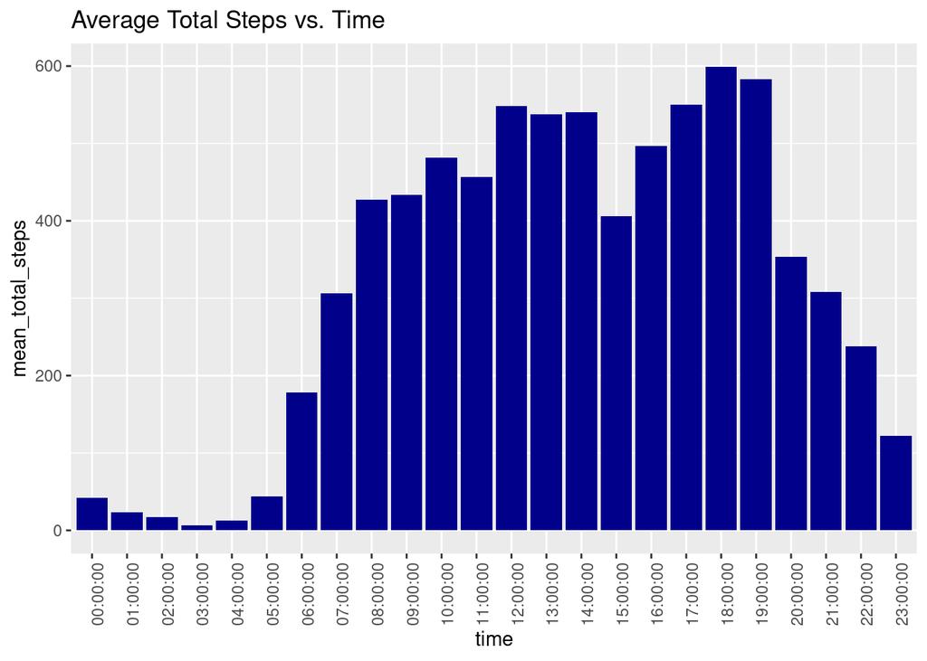

```r
ggplot(data=steps_new, aes(x = time, y = mean_total_steps)) + geom_histogram(stat = "identity", fill='darkblue') +
  theme(axis.text.x = element_text(angle = 90)) +
  labs(title="Average Total Steps vs. Time")
```

Let’s take a look at intensities table to cross check intensities level vs time of the day. We will create a bar chart to illustrate this relationship.

```r
intensities_new <- intensities %>%
  group_by(time) %>%
  drop_na() %>%
  summarise(mean_total_int = mean(TotalIntensity))
```

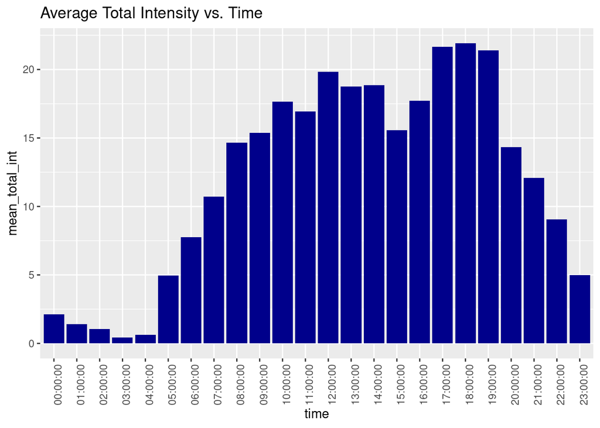

```r
ggplot(data=intensities_new, aes(x=time, y=mean_total_int)) + geom_histogram(stat = "identity", fill='darkblue') +
  theme(axis.text.x = element_text(angle = 90)) +
  labs(title="Average Total Intensity vs. Time")
```

If we examine two bar charts we can conclude that they mainly overlap, peaking between 5pm and 8 pm, with a significant increase during the lunch hours. It might mean that most of the users are employed and have relatively sedentary jobs like office jobs, considering the amount of sedentary hours. The users tend to do more steps during lunch and after 5 pm, which further confirms our theory regarding their uccupations and lifestyle.